# Лекция 1. Вводная лекция: основные понятия и термины.

1. Определение информационных ресурсов, информационных систем.
2. Классификация информационных ресурсов. Рынок информационных ресурсов.
3. Классификация информационных систем. Управление информационными ресурсами.
4. Интегрированные информационные системы управления информационными ресурсами предприятий.

## 1. Определение информационных ресурсов, информационных систем.

Любой субъект (мировое сообщество, конкретное государство, регион, город или район, организация, предприятие или хозяйство, отдельный человек или группа лиц) для своей деятельности располагает определенными объемами и видами ресурсов.

Последние подразделяются на отдельные виды ресурсов относительно определенных предметных областей жизни и деятельности человека. Например:

- **материальные** (совокупность предметов труда, используемых в процессе производства общественного продукта — сырье материалы, топливо, полуфабрикаты и т. п.),
- **природные** (естественные ресурсы — объекты, процессы, условия природы, используемые для удовлетворения материальных и духовных потребностей людей),
- **энергетические** (носители энергии — нефть, газ и др.),
- **трудовые** (люди, владеющие общеобразовательными и профессиональными знаниями),
- финансовые, товарные, нематериальные (духовные или интеллектуальные) и др.

Перечисленные ресурсы имеют первостепенное значение для материального производства особенно в эпоху индустриального общества.

В отличие от большинства перечисленных выше ресурсов **информационные ресурсы** (ИР) являются продуктом интеллектуальной деятельности наиболее квалифицированной и творческой части населения, составляют значительную часть национального богатства и относятся к числу возобновляемых благ, так как имеют способность к тиражированию в зависимости от общественной потребности.

В большей своей части эти ресурсы материализованы в виде книг, статей, документов, баз данных, баз знаний, алгоритмов, компьютерных программ, произведений искусства, литературы и т.п. По существу, эти накопленные людьми знания на протяжении своей истории существования и развития, зачастую отчужденные от своих создателей, рассматриваются как общие стратегические ресурсы, принадлежащие всему человечеству.

Информационные ресурсы объединяют первичную информацию, отражающую знания человека об опыте своей деятельности и сведения об окружающей среде, а также всю вторичную информацию, образующуюся в результате обработки и переработки всей получаемой информации.

С одной стороны определенный объем ИР составляют знания людей, специалистов (экспертные знания). Объем этих знаний неуклонно возрастает в результате более совершенных и целенаправленных научных исследований, ведущих к открытиям и научно-техническим достижениям, более глубокого и широкого образования населения, развития и повсеместно используемых современных средств вычислительной техники, коммуникаций, связи и других факторов.

С другой стороны, основная и большая часть ресурсов представляет собой накопленную информацию, которая фиксировалась на различных носителях на протяжении всего исторического пути развития человечества и продолжает накапливаться и фиксироваться в настоящее время весьма быстрыми темпами (за счет использования современных компьютерных и коммуникационных средств).

Следует отметить, что обмен информацией в результате общения и коммуникаций присущ всей живой природе (по некоторым учениям нематериалистического характера и неживой), однако только человеку принадлежит свойство глубокого познания окружающего мира, извлечения из него разнообразной информации, ее анализа и на этой базе генерирования и накапливания новых знаний. Именно это - формирование и использование ИР - отличает человека от всего живого и позволяет ему не только осознанно ориентироваться в окружающей обстановке, но и создавать вокруг себя общественные богатства, строить социальные отношения и обеспечивать свою жизнедеятельность с помощью научно-технических достижений.

Чрезвычайно важно то обстоятельство, что определенным образом собранная и целенаправленно обработанная информация порождает новые знания. Таким образом, информация обладает уникальным свойством репродуцировать (воспроизводить) знания и усиливать эффект их накопления (суммирования), что приводит к постоянному росту ИР.

Следует отметить, что практически до последней четверти ХХ в. ИР не рассматривались с позиций общественно значимой экономической или иной категории, влияющей на состояние и развитие страны. В основном обращалось внимание на культурное наследие той или иной национальности или государства. В настоящее время в эпоху постиндустриального развития общества по своей эффективности использования, важности, полезности и степени значимости ИР играют все большую роль и рассматриваются как приоритетные стратегические ресурсы, сопоставимые с материальными и энергетическими ресурсами.

На текущий момент всю деятельность по формированию, учету и контролю информационных ресурсов регламентирует **Федеральный закон от 27.07.2006 N 149 "Об информации, информационных технологиях и о защите информации" (ред. от 30.12.2021, вступил в силу с 01.01.2022)**.

В текущей редакции ФЗ в большей степени направлен на функции контроля за создаваемыми информационными ресурсами, которые следует относить к категории "**новостной агрегатор**", а также за владельцами аудивизуальных сервисов, за распространением информации в социальных сетях. Законом также устанавливаются принципы государственного регулирования в сфере применения информационных технологий.

В законе дано определение информационной системы и предложена их некоторая классификация.

**Информационная система** - это совокупность содержащейся в базах данных информации и обеспечивающих ее обработку информационных технологий и технических средств.

**Информация** - сведения (сообщения, данные) независимо от формы их представления.

**Информационные технологии** - процессы, методы поиска, сбора, хранения, обработки, предоставления, распространения информации и способы осуществления таких процессов и методов.

**Информационно-телекоммуникационная сеть** - технологическая система, предназначенная для передачи по линиям связи информации, доступ к которой осуществляется с использованием средств вычислительной техники.

**Электронное сообщение** - информация, переданная или полученная пользователем информационно телекоммуникационной сети.

**Документированная информация** - зафиксированная на материальном носителе путем документирования информация с реквизитами, позволяющими определить такую информацию или в установленных законодательством Российской Федерации случаях ее материальный носитель.

**Электронный документ** - документированная информация, представленная в электронной форме, то есть в виде, пригодном для восприятия человеком с использованием электронных вычислительных машин, а также для передачи по информационно-телекоммуникационным сетям или обработки в информационных системах.

**Cайт в сети "Интернет"** - совокупность программ для электронных вычислительных машин и иной информации, содержащейся в информационной системе, доступ к которой обеспечивается посредством информационно-телекоммуникационной сети "Интернет" по доменным именам и (или) по сетевым адресам, позволяющим идентифицировать сайты в сети "Интернет".

**Cтраница сайта в сети "Интернет"** - часть сайта в сети "Интернет", доступ к которой осуществляется по указателю, состоящему из доменного имени и символов, определенных владельцем сайта в сети "Интернет".

**Доменное имя** - обозначение символами, предназначенное для адресации сайтов в сети "Интернет" в целях обеспечения доступа к информации, размещенной в сети "Интернет".

**Cетевой адрес** - идентификатор в сети передачи данных, определяющий при оказании телематических услуг связи абонентский терминал или иные средства связи, входящие в информационную систему.

**Идентификация** - совокупность мероприятий по установлению сведений о лице и их проверке, осуществляемых в соответствии с федеральными законами и принимаемыми в соответствии с ними нормативными правовыми актами, и сопоставлению данных сведений с уникальным обозначением (уникальными обозначениями) сведений о лице, необходимым для определения такого лица (далее - идентификатор).

**Аутентификация** - совокупность мероприятий по проверке лица на принадлежность ему идентификатора (идентификаторов) посредством сопоставления его (их) со сведениями о лице, которыми располагает лицо, проводящее аутентификацию, и установлению правомерности владения лицом идентификатором (идентификаторами) посредством использования аутентифицирующего (аутентифицирующих) признака (признаков) в рамках процедуры аутентификации, в результате чего лицо считается установленным.

В новом ФЗ отсутствует определение понятия "информационный ресурс", однако данный термин очень часто используется этом нормативно-правовом документе. В этом отношении, следуя правилу приемственности, можно использовать определение этого понятия, принятого в более старой версии этого федерального закона №24 от 25 января 1995 года.

**Информационные ресурсы** - отдельные документы и отдельные массивы документов, документы и массивы документов в информационных системах (библиотеках, архивах, фондах, банках данных, других информационных системах).

Учитывая, что эта формулировка носит статический характер наличия или хранения сведений и не затрагивает большую и чрезвычайно важную часть знаний, которыми обладают отдельные люди, образованные и информированные в определенных областях науки и техники, медицины и биологии, литературы и искусства и т. д. (учителя, врачи, ученые, инженеры и т. д., одним словом, эксперты), целесообразно понятие ИР представить шире с учетом динамических свойств, рассматриваемых в моменты передачи информации и ее восприятия. Отсюда это понятие можно представить так:

**Информационный ресурс**— это индивидуальные и коллективные экспертные знания, отдельные документы, отдельные массивы документов, а также документы и их массивы, составляющие базы и банки данных, базы знаний, библиотеки, архивы, фонды, информационные системы и другие системы в определенной предметной тематической области, которые удовлетворяют функциональным потребностям и запросам потребителей информации.

## 2. Классификация информационных ресурсов. Рынок информационных ресурсов.

Информационными ресурсами обладают отдельные люди, коллективы людей, организации, территориальные и национальные образования, города, регионы, страны и в целом весь мир. Если ИР собирается и используется в рамках региона или в рамках одной страны, то говорят о региональных или национальных, государственных ИР.

Государственные информационные ресурсы в России включают:

- федеральные информационные ресурсы;
- информационные ресурсы, находящиеся в совместном ведении Российской Федерации и субъектов Российской Федерации (информационные ресурсы совместного ведения);
- информационные ресурсы субъектов Российской Федерации.

В том случае если информация пересекает государственные границы и используется на межгосударственном или межнациональном уровне, то говорят о мировых информационных ресурсах. Учитывая развитие современных информационных технологий, прежде всего повсеместное расширение в мире глобальной сети Интернет, государственные границы для информации теряют свое значение, и она становится доступной для всего человечества. Поэтому вся совокупность ИР, накопленных различными лицами, организациями, регионами, государствами и используемых на межгосударственном уровне, называется **мировыми информационными ресурсами**.

За последние годы широкое использование компьютеров и микропроцессоров, сетей передачи данных, спутниковых и наземных каналов связи позволило объединить мир в единую гигантскую систему, практически не имеющую границ и обеспечивающую хранение колоссальных по объему разнообразных ИР, пополнение и широкие возможности их освоения. Разрабатываются новые методы, оптимизирующие процессы обработки информации (например, распараллеливание процессов), ее хранения (например, сжатие) и распространения.

Происходит переход к "безбумажной" технологии и "безбумажному" обществу, в котором ИР представляются в основном в цифровом или электронном виде, а информационный обмен между людьми осуществляется с помощью электронных средств (Интернета, электронной почты, видеотелефона, видеоконференций, факсимильной связи и т. п.). Хранение и обработка любой информации при этом производится в цифровом виде на персональных компьютерах (объединенных развитой телекоммуникационной сетью), что по своей сути является переходом к новой - шестой фазе развития и потребления ИР.

Современные информационные технологии по формированию и использованию ИР привели к созданию информационной индустрии, которая по своим масштабам и экономическим показателям опередила энергодобывающую, промышленную и сельскохозяйственную индустрии. Она связана как непосредственно с поиском и предоставлением информации, так и с разработкой программного и технического обеспечения и продажей его все большему числу пользователей. При этом возникла проблема экономической оценки как самих ИР, так процессов их хранений и передачи. Появились множественные службы и организации по управлению и распространению ИР, а также программных и технических средств их хранения, переработки и доставки.

В итоге развитие мировых ИР и эволюция информационных технологий на настоящий момент позволили:

- формировать новые ИР на базе более эффективных методов и средств автоматизации и информатизации;
- превратить деятельность по оказанию информационных услуг в глобальную человеческую деятельность;
- сформировать мировой и внутригосударственный рынок информационных услуг;
- образовать всевозможные базы данных по ресурсам регионов и государств;
- более эффективно использовать имеющиеся ИР для повышения обоснованности и оперативности принимаемых решений по управлению как в технических и организационно-экономических системах (например, в фирмах, банках, биржах, в промышленности, торговли и т.п.), так в социальной и других сферах.

Для классификации ИР и разбиения их на определенные виды или категории можно использовать разнообразные признаки. Наиболее обобщенным признаком служит признак формы представления или фиксации информации. В соответствии с этим признаком классификация ИР представлена на рисунке.

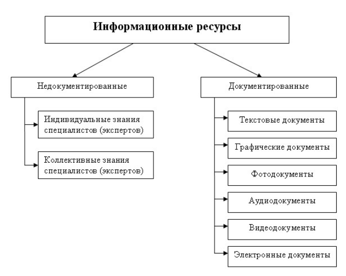

Исходя из приведенной классификации, все ИР целесообразно разбить на два класса: недокументированные, к которому относят индивидуальные и коллективные знания специалистов, и документированные.

Документированные ИР по признаку закрепления информации подразделяют на текстовые (письменные), графические(чертежи, схемы, графики, карты, диаграммы, картины), фото-, аудио- (грампластинки, аудиокассеты и т. п.), видео- (кинофильмы, диапозитивы, слайды и т. п.) и электронные документы.

По признаку фиксации информации документированные ИР можно также разделить на два класса: зафиксированная и хранящаяся на различного типа материальных носителях (различные материалы: бумага, холст, глина, парафин, фотопленка, кинопленка, магнитная пленка и т. п.) и преобразованная и зафиксированная в электронном виде (память компьютера, дискетка, компакт-диск и т.п.).

По признаку подлинности документированные ИР подразделяются на документы-оригиналы и копированные, или репродуцированные, документы (микрофиши, микрофильмы, ксерокопии. фотокопии и т.п.).

По признаку тематической принадлежности ИР могут быть подразделены на множество тематических областей и подоблестей знаний, например:

- научные ресурсы;
- социальные ресурсы;
- экологические ресурсы;
- законодательные ресурсы
- нормативно-правовые ресурсы;
- статистические ресурсы;
- обучающие ресурсы и т.д.

Использовать данный признак классификации ИР достаточно сложно, так как один и тот же ресурс может содержать информацию по ряду разнообразных тем. В таком случае ИР включают в соответствующие тематикам виды, и, таким образом, он может встречаться многократно в разных списках.

По признаку ограничения доступа ИР подразделяются на ряд классов, которые определяются законодательством страны или внутренними положениями организаций, владеющих информацией. Так, в Законе "Об информации, информационных технологиях и о защите информации" сказано, что "доступ к информации - это возможность получения информации и ее использования" (ст. 2, п. 6); "конфиденциальность информации — обязательное для выполнения лицом, получившим доступ к определенной информации, требование не передавать такую информацию третьим лицам без согласия ее обладателя" (ст. 2, п. 7); "ограничение доступа к информации устанавливается федеральными законами в целях защиты основ конституционного строя, нравственности, здоровья, прав и законных интересов других лиц, обеспечения обороны страны и безопасности государства" (ст. 9, п. 1).

Также в Законе прописано: "Информация в зависимости от категории доступа к ней подразделяется на общедоступную информацию, а также на информацию, доступ к которой ограничен федеральными законами (информация ограниченного доступа)" (ст. 5, п. 2) и "Информация в зависимости от порядка ее предоставления или распространения подразделяется:

- на информацию, свободно распространяемую;
- информацию, предоставляемую по соглашению лиц, участвующих в соответствующих отношениях;
- информацию, которая в соответствии с федеральными законами подлежит предоставлению или распространению;
- информацию, распространение которой в Российской Федерации ограничивается или запрещается" (ст. 5, п. 3).

Таким образом, информация в зависимости от категории доступа разбита на два класса: общедоступную информацию и информацию ограниченного доступа, и в зависимости от порядка ее предоставления или распространения — на 4 класса.

Следует отметить, что Закон гласит: "Федеральными законами устанавливаются условия отнесения информации к сведениям, составляющим коммерческую тайну, служебную тайну и иную тайну, обязательность соблюдения конфиденциальности такой информации, а также ответственность за ее разглашение" (ст. 9, п. 4).

По признаку коммерциализации ИР можно разделить:

- на некоммерческие ресурсы (открытые государственные и отраслевые публичные библиотеки, фонды, хранилища, музеи, передачи по общедоступным каналам эфирного или кабельного телевидения и радио, бесплатное образование и т. п.);
- коммерческие ресурсы (конкретный информационный продукт, имеющий определенную стоимость и продаваемый по рыночной цене, или платный доступ в библиотеки, фонды, хранилища, музеи, к системе платного телевидения, в информационные системы, в том числе Интернете и т.д.).

ИР от отправителя (коммуникатора) к потребителю (реципиенту) распространяются с помощью устных, документальных и электронных каналов передачи информации. При этом возможны четыре варианта коммерциализации процесса:

- предоставление ресурса бесплатно, получение бесплатное;
- предоставление ресурса бесплатное, получение платное;
- предоставление ресурса платное, получение бесплатное;
- предоставление ресурса платное, получение платное.

В рекламном бизнесе принято предоставлять ИР на платной основе, а получать рекламную информацию бесплатно (по телевидению и радио, путем рассылки газет, рекламных брошюр, установки рекламных щитов и плакатов и т. п.).

Для доступа в Интернет провайдерами устанавливается определенная плата в зависимости от объема получаемой информации или времени нахождения в сети. При этом отдельные ресурсы предоставляются бесплатно, а некоторые имеют свою цену, которую необходимо оплатить предварительно перед получением информации.

Информатизация общества с учетом индустриального развития и совершенствования методов и средств получения, обработки, преобразования, передачи и использования информации ведет к устранению человека от рутинных операций в работе, обеспечению высокого уровня автоматизации в производственной и социальной сферах, а значит, к снижению материала- и энергоемкости производства и повышению его эффективности, т.е. решающим образом влияет на уровень экономического развития страны, ее обороноспособность и на все стороны проявления социальной деятельности граждан.

В высокоразвитом информационном обществе должно измениться не только производство, но и весь уклад жизни, система ценностей, при которой возрастает значимость культурного досуга по отношению к материальным ценностям. По сравнению с индустриальным обществом, где все направлено на производство и потребление товаров, в информационном обществе производятся и потребляются интеллект, знания, что приводит к увеличению доли умственного труда. От человека потребуется способность к творчеству, возрастет спрос на знания.

Таким образом, деятельность людей будет сосредоточена главным образом на создании и использовании ИР, а производство материальных и энергетических ресурсов в большей своей части будет возложено на машины. В настоящее время закладываются основы построения единого мирового информационного пространства, объединяющего все человечество в информационное сообщество людей.

Материальной и технологической базой информационного общества являются различного рода системы на базе компьютерной техники и компьютерных сетей, информационной технологии, телекоммуникационной связи.

Ряд ученых выделяют характерные черты информационного общества:

- решена проблема информационного кризиса, т.е. разрешено противоречие между информационной лавиной и информационным голодом;
- обеспечен приоритет информации по сравнению с другими ресурсами, при этом главной формой развития станет информационная экономика;
- в основу общества будут заложены автоматизированные генерация, хранение, обработка и использование знаний с помощью новейшей информационной техники и технологии;
- информационная технология приобретет глобальный характер, охватывая все сферы социальной деятельности человека;
- формируется информационное единство всей человеческой цивилизации;
- с помощью средств информатики реализован свободный доступ каждого человека к информационным ресурсам всей цивилизации;
- реализованы гуманистические принципы управления обществом и воздействия на окружающую среду.

Кроме положительных моментов прогнозируются и опасные тенденции:

- все большее влияние на общество средств массовой информации;
- информационные технологии могут разрушить частную жизнь людей и организаций;
- существует проблема отбора качественной и достоверной информации;
- многим людям будет трудно адаптироваться к среде информационного общества;
- существует опасность разрыва между "информационной элитой" (людьми, занимающимися разработкой информационных технологий) и потребителями.

**Рынок информационных ресурсов**

Информатизация общества неразрывно связана с возникновением и развитием рынка информационных продуктов и услуг, который представляет собой систему экономических, правовых и организационных отношений в сфере свободной купли-продажи товаров интеллектуального труда и услуг между различными субъектами хозяйствования и потребителями.

Этот рынок, как и другие рынки, характеризуется определенной номенклатурой продуктов и услуг, условиями и механизмами их предоставления, ценами.

Характерными чертами рыночных отношений являются: наличие конкуренции, свободный выбор партнеров, взаимные соглашения обменивающихся сторон, эквивалентный обмен товаров и денежных средств и т.д., что обеспечивает возможность эффективного решения социально-экономических проблем.

В качестве товаров интеллектуального труда на этом рынке выступают информационные продукты: знания, документы, информационные системы, информационные технологии, лицензии, патенты, товарные знаки, ноу-хау, инженерно-технические услуги, различного рода информация и прочие виды информационных ресурсов.

В рыночных понятиях товар интеллектуального труда имеет совокупность многих свойств, соответствующих товару материально-вещественной или энергетической формы, т. е. любому продукту труда, произведенного для купли-продажи (обмена) и являющемуся предметом торговли.

Понятию **информационная услуга** кроме основного определения — подготовку, получение и предоставление в распоряжение пользователя информационных ресурсов — можно дать следующие характеристики:

- результат информационной деятельности или информационных процессов;
- конкретный результат материального или духовного производства, обладающий качествами, характеризующими его целевое назначение, и информационными свойствами, ради которых он приобретается и потребляется;
- комплекс осязаемых и неосязаемых свойств (характеристик, функций, выгод и использований), предназначенных для удовлетворения информационных нужд покупателей;
- результат непроизводственной деятельности предприятия или лица, направленный на удовлетворение информационных потребностей человека или организации в использовании различных продуктов.

Уникальность информационных услуг предопределяет специфику рыночных отношений. Перечень предлагаемых на рынке информационных услуг определяется объемом, качеством, предметной ориентацией в сфере использования информационных ресурсов. Обобщая вышесказанное, понятие информационной услуги можно определить следующим образом:

**Информационная услуга** - удовлетворение со стороны информационной системы, собственника или владельца информационного ресурса заявки пользователя на подготовку и получение в согласованных условиях некоторого информационного ресурса определенной тематической направленности, заданного вида и конечного объема.

При предоставлении услуги заключается соглашение (договор) между двумя сторонами - предоставляющей и использующей услугу.

**Рынок информационных услуг** - совокупность отношений между потребителями (товаропроизводителями) и субъектами предложения, включающих взаимодействия по поводу производства, приобретения, использования информации путем консультаций, образовательной, издательской, рекламной и правовой деятельности.

Рынок информационных услуг в процессе своего функционирования выполняет шесть основных функций:

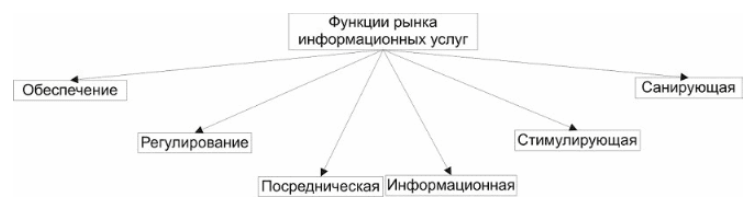

1) функция обеспечения - удовлетворяет потребности каждого участника либо в приобретении (получении), либо в сбыте информации; 2) функция регулирования: оптимально формирует структурные пропорции в общем объеме информационных услуг разного вида как с точки зрения спроса (потребления), так и с точки зрения их предложения; обеспечивает рациональное распределение и обмен информацией между всеми субъектами рынка; устанавливает уровень и зависимость движения цен (расценок) на информационные услуги под влиянием спроса и предложения; 3) посредническая функция - позволяет осуществлять обмен информационными услугами между поставщиками и потребителями; 4) информационная функция - обеспечивает распространение всей необходимой информации для активного и выгодного участия субъекта в рыночных отношениях; 5) стимулирующая функция: способствует повышению качества и расширению ассортимента информационных услуг на основе конкуренции; нацеливает поставщиков услуг на эффективную деятельность за счет изыскания наиболее оптимальных способов оказания услуг (достижение минимизации издержек при высоком качестве); 6) санирующая функция - повышает конкурентоспособность, в противном случае механизм конкурентной борьбы санирует рынок от неконкурентоспособных участников.

Потребителями информационных продуктов и услуг могут быть различные юридические и физические лица - специалисты, работающие почти во всех сферах производства и нуждающиеся в дополнительных знаниях. Они могут быть разделены на следующие группы:

- работники научно-исследовательских учреждений и учебных заведений;
- специалисты промышленных предприятий, фирм и предприятий торговли;
- специалисты консалтинговых и маркетинговых информационных агенств;
- работники государственных учреждений;
- работники общественных организаций;
- индивидуальные пользователи. Потребители информационных ресурсов нуждаются в информации, которую целесообразно разделить на следующие категории:

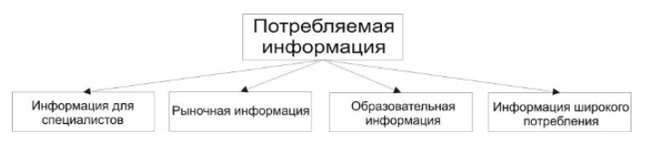

**Информация для специалистов** содержит научную, инженерно-техническую, конструкторскую, проектную, а также гуманитарную, т.е. профессиональную, информацию (документальную, библиографическую, реферативную, справочную) в области естественных, технических, общественных наук, по отраслям производства и сферам человеческой деятельности (в промышленности, сельском хозяйстве, вооруженных силах, окружающей среде, социальной сфере, медицине и здравоохранении, в сфере государственного управления, культуре и т.д.), предназначенную для узкого круга специалистов - ученых, инженеров, конструкторов, историков, юристов, врачей, геологов и т.д.

На стадии фундаментальных исследований необходима следующая научная и инженерно-техническая информация:

- сведения о последних достижениях науки и техники;
- информация о тенденциях развития данного вида техники;
- сведения о патентах;
- другие На стадии прикладных исследований, конструкторских разработок и технологического освоения требуется следующая информация:
- сведения о новых научно-технических достижениях и НИОКР;
- сведения о совокупности затрат на разработку и производство;
- описание техники возможного производства;
- характеристика периода морального старения объектов техники;
- данные о затратах на изготовление;
- сведения о сырье и оборудовании;
- предложения фирм по материалам, комплектующим изделиям;
- сведения по стандартизации, сертификации и т.д

На стадии производства идет отбор, анализ, внедрение научно-технической документации и оценка технических условий, что требует информации о мировых, региональных, национальных, отраслевых классификационных и оценочных показателях.

На стадиях эксплуатации, модернизации, утилизации необходима конъюнктурная и маркетинговая информация.

Кроме того, нужна правовая охрана промышленной и интеллектуальной собственности, создаваемой производителем, в том числе информации о патентной ситуации, о реализации патентирования, лицензирования, экспертизы; о целесообразности приобретения лицензий и "ноу-хау" других фирм; о возможности коммерческого использования интеллектуальных продуктов инновационного цикла: патенты изобретений, принципиальные схемы, публикации, макеты изделий, образцы, чертежно-конструкторская документация, технологические образцы, технологическая документация, эксплуатационная документация, технология утилизации, сведения о законодательных и нормативных актах и их практическом применении.

**Рыночная информация** состоит из биржевой и финансовой информации (котировки ценных бумаг, валютные курсы, учетные ставки, рынок товаров и капиталов, инвестиции, цены и т.п.), маркетинговой информации (структура рынка, сегмент предприятия на рынке, спрос, предложения, потребители, конкуренты, конкурирующие товары, поставщики, общеэкономические тенденции), коммерческой бизнес-информации (общая информация по финансовому рейтингу, финансовая информация по активам и пассивам фирмы, по обороту, по стоимости продаж, кредитно-аналитическая информация по ликвидности по коэффициентам рентабельности, платежно-аналитическая информация, сроки исполнения платежей, сведения о компаниях, фирмах, корпорациях, направлении работы и их продукции, ценах на продукцию; о финансовом состоянии, связях, сделках, руководителях, деловых новостей в области экономики и бизнеса и т.п.)

Основными потребителями биржевой информации в России являются профессиональные участники биржевого, фондового и финансового рынков - оптовики, профессиональные инвесторы, а также аналитические и консультационные службы, ориентированные на их обслуживание.

Специфика этого вида информации заключается в том, что она ежеминутно меняется, отражая события, происходящие на рынке, и включает сведения о ценных бумагах, фьючерсах, обменных курсах валют, рынке недвижимости, денег, капитала и страхования. Финансовый рынок как форма организации и регулирования жизни общества представляет собой, прежде всего, определенную информационную систему.

Поэтому главное условие успеха деятельности на финансовом рынке - владение оперативной и достоверной информацией.

**Образовательная информация** направлена на познавательные цели и может быть представлена в компьютерном и некомпьютерном виде: учебники, методические разработки, практикумы, развивающие компьютерные игры, компьютерные обучающие и контролирующие системы, методики обучения т.п. для всех форм и ступеней образования: дошкольного, школьного, специального, среднепрофессионального, высшего, повышения квалификации и переподготовки.

Информация этого рода наиболее проверенная на практике и временем и представляет собой устоявшиеся сведения из основных направлений деятельности человека.

**Информация широкого потребления** состоит из новостной (газеты, журналы, новости по радио и телевидению, новости агентств прессы и т.п.), справочно-потребительской (справочники, энциклопедии, расписание транспорта, резервирование билетов и мест в гостиницах, заказ товаров и услуг, банковские операции и т.п.) и развлекательной информации (игры, телетекст, видеотекст и т.п.), а также информации художственно-эстетического толка (кинофильмы, театральные постановки, музейные и другие выставки, и т.п.).

В качестве источников и поставщиков информации на рынке информационных продуктов и услуг выступают государственные, коммерческие структуры, общественные организации и частные лица. Обычно они именуются информационными корпорациями, информационными агентствами, информационными службами, информационными центрами.

Основным источником информации для информационного обслуживания в современном обществе являются базы данных. Поиск в базе данных, содержащих необходимые данные или сведения о них, в режиме теледоступа представляется более рациональным, чем сбор этих видов изданий.

Онлайновые базы данных принято подразделять на БД, ориентированные на массового (consumer online) и на профессионального (databases for professionals) потребителя.

По сравнению с БД для массового потребителя профессиональные БД обычно имеют больший объем, содержат более полную информацию, уровень структуризации данных в них выше, поисковая система более развита. Подавляющее большинство информационных ресурсов Интернета обычно рассматривают как БД для массового потребителя. Они имеют весьма скромные характеристики.

На мировом рынке поставщиков рыночной информации представлено более чем 6 тыс. крупных информационных агентств, в полном объеме обеспечивающих разнообразные потребности в информации различных видов бизнеса. Эти агентства предоставляют услуги доступа к 13,5 тыс. крупных информационных баз, содержащих биржевую, и финансовую информацию, сведения о фирмах, товарах, услугах, рынках сбыта, статистическую, научно-техническую, правовую информацию и деловые новости. К большинству баз имеется режим непосредственного доступа из любой точки мира.

Наряду с собранной из различных источников информацией об интересующей вас фирме, ряд информационных агентств предоставляет потребителям информацию с собственной оценкой финансового состояния этой фирмы, что крайне важно при установлении партнерских отношений или рассмотрении вопроса о выдаче кредита.

Основная информация из профессиональных баз (свыше 85%) предоставляется на коммерческой основе. Несмотря на относительно высокие цены, спрос на информацию постоянно растет.

Ряд федеральных органов управления можно назвать исключительно информационными, поскольку их главной задачей является формирование государственных информационных ресурсов. В это число входят:

- Министерство культуры РФ;
- Федеральная служба государственной статистики;
- Федеральное агентство по техническому регулированию и метрологии;
- Министерство природных ресурсов и экологии РФ;
- Федеральная служба по гидрометеорологии и мониторингу окружающей среды (Росгидромет) и др.

Государственные информационные ресурсы могут быть разделены на группы: 1) предназначенные для решения задач конкретного органа управления определенного звена; 2) ориентированные на внешнего пользователя. Информационные ресурсы второй группы формируются, как правило, информационными или информационно-аналитическими структурами. Если эти структуры имеют общее методическое руководство, схожие задачи, решаемые на основе единых нормативных документов, то они могут быть названы государственными информационными системами. К таким системам, имеющим межведомственный, универсальный характер, может быть отнесена библиотечная сеть и архивный фонд.

Производители и поставщики рыночной информации, как правило, представляют не только биржевую, финансовую, маркетинговую информацию, коммерческую бизнес-информацию, но и общие сведения по текущей экономике и политике в стране и в мире, новости и многое другое.

Поставщиков рыночной информации можно разделить на три группы.

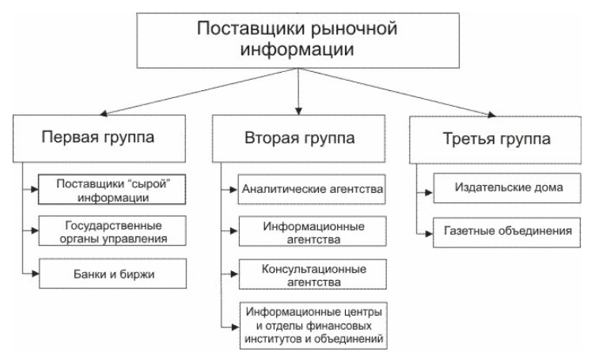

К первой группе относятся следующие:

- поставщики "сырой" финансовой информации - финансовые институты и службы, дающие первичную и оперативную биржевую и другую информацию;
- государственные органы управления, такие как ЦБ РФ и Министерство финансов РФ;
- банки, биржи.

Вторую группу составляют аналитические, информационные и консультационные агентства, информационные центры и отделы финансовых институтов и объединений.

Среди них: РосБизнесКонсалтинг (РБК) https://www.rbc.ru/; Акционерное общество "Анализ, консультации и маркетинг" (АК&М) https://www.akm.ru/; ; Информационное агентство "Финмаркет" http://www.finmarket.ru/; Агентство экономической информации "ПРАЙМ-ТАСС" https://1prime.ru/; Общество с ограниченной ответственностью МФД "ИнфоЦентр" https://mfd.ru/; Агентство Интерфакс https://www.interfax.ru/; Агентство экономических новостей (АЭН) https://www.myeconomy.ru/; и др.

Третью группу образуют издательские дома и газетные объединения, такие как "Финансовая газета" https://www.gazeta.ru/tags/media/finansovaya_gazeta.shtml, "Экономика и жизнь" https://www.eg-online.ru/, Издательский дом "Коммерсантъ" https://www.kommersant.ru/, ИТАР-ТАСС https://tass.ru/ и др.

## 3. Классификация информационных систем. Управление информационными ресурсами.

Управление информационными ресурсами невозможно без использования информационных систем.

Классификация информационных систем возможна по различным признакам:

- **по выполняемым государственным функциям**;
- **по характеру представления и логической организации хранимой информации**;
- **по функциональному признаку**;
- **по уровню управления**;
- **по степени автоматизации**.

При классификации по выполняемым государственным функциям выделяют:

- **государственные информационные системы** - федеральные информационные системы и региональные информационные системы, созданные на основании соответственно федеральных законов, законов субъектов Российской Федерации, на основании правовых актов государственных органов;
- **муниципальные информационные системы**, созданные на основании решения органа местного самоуправления;
- **иные** информационные системы.

  Государственные информационные системы создаются в целях реализации полномочий государственных органов и обеспечения обмена информацией между этими органами, а также в иных установленных федеральными законами целях.

  Государственные информационные системы создаются и эксплуатируются на основе статистической и иной документированной информации, предоставляемой гражданами (физическими лицами), организациями, государственными органами, органами местного самоуправления.

Правительство Российской Федерации определяет случаи, при которых доступ с использованием сети "Интернет" к информации, содержащейся в государственных информационных системах, предоставляется исключительно пользователям информации, прошедшим авторизацию в единой системе идентификации и аутентификации, а также порядок использования единой системы идентификации и аутентификации.

По характеру представления и логической организации хранимой информации выделяют:

**Фактографические информационные системы** накапливают и хранят данные в виде множества экземпляров одного или нескольких типов структурных элементов (информационных объектов). Каждый из таких экземпляров или некоторая их совокупность отражают сведения по какому-либо факту, событию отдельно от всех прочих сведений и фактов.

В **документальных (документированных) информационных системах** единичным элементом информации является нерасчлененный на более мелкие элементы документ и информация при вводе (входной документ), как правило, не структурируется, или структурируется в ограниченном виде. Для вводимого документа могут устанавливаться некоторые формализованные позиции (дата изготовления, исполнитель, тематика).

В **геоинформационных системах** данные организованы в виде отдельных информационных объектов (с определенным набором реквизитов), привязанных к общей электронной топографической основе (электронной карте). Геоинформационные системы применяются для информационного обеспечения в тех предметных областях, структура информационных объектов и процессов в которых имеет пространственно-географический компонент (маршруты транспорта, коммунальное хозяйство).

Классификация по функциональному признаку:

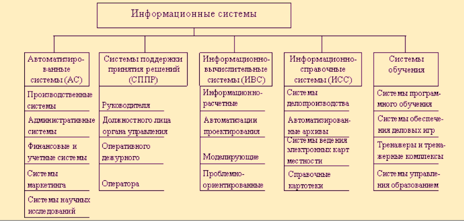

Классификация по уровням управления:

- информационные системы **оперативного (операционного) уровня** – бухгалтерская, банковских депозитов, обработки заказов, регистрации билетов, выплаты зарплаты;
  - **информационная система специалистов** – офисная автоматизация, обработка знаний (включая экспертные системы);
  - информационные системы **тактического уровня** (среднее звено) – мониторинг, администрирование, контроль, принятие решений;
  - **стратегические информационные системы** – формулирование целей, стратегическое планирование.

Классификация по степени автоматизации:

- **Автоматические информационные системы** выполняют все операции по переработке информации без участия человека.
- **Автоматизированные информационные системы** предполагают участие в процессе обработки информации и человека, и технических средств, причем главная роль отводится компьютеру.

**Основные компоненты ИС**

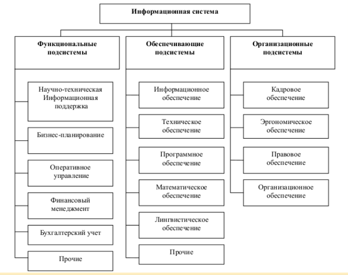

ИС реализуют и поддерживают модели, методы и алгоритмы получения управляющей информации. Состав функциональных подсистем зависит от предметной области использования ИС.

Состав **обеспечивающих систем** достаточно стабилен и по большей части мало зависит от предметной области использования ИС. Отметим следующие компоненты:

- Программное обеспечение – совокупность программ регулярного применения, необходимых для решения функциональных задач, и программ, позволяющих наиболее эффективно использовать вычислительную технику, обеспечивая пользователям наибольшие удобства в работе.
- Математическое обеспечение – совокупность методов, моделей и алгоритмов обработки информации, используемых в системе.
- Лингвистическое обеспечение – совокупность языковых средств. Обычно включает комплекс языков, отражающий многоуровневость представления информации в АИС, и в том числе язык запросов и отчетов, обеспечивающий удобство работы конечному пользователю, специальные языки определения и управления данными, обеспечивающие адекватность внутреннего представления и согласование внутреннего и внешнего представлений. В наибольшей степени определяется особенностями предметной области.

**Организационные подсистемы** также относятся к обеспечивающим подсистемам, но направлены в первую очередь на обеспечение эффективной работы персонала и поэтому могут быть выделены отдельно.

Разработка ИС должна начинаться именно с создания организационного обеспечения: экономического обоснования целесообразности системы, состава экономических показателей, состава функциональных подсистем, организационной структуры управления.

**Использование технологии клиент-сервер при построении информационных систем**

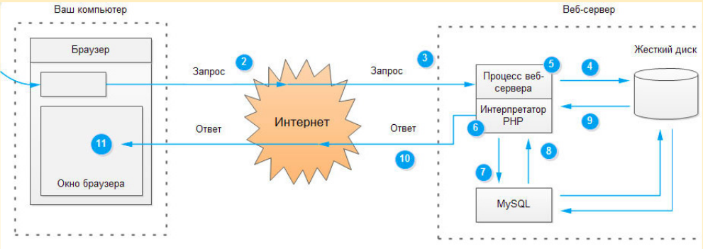

**Примеры информационных систем в рамках концепции открытых данных**

[figure not shown]

**Обобщенная структура информационных технологий предприятия**

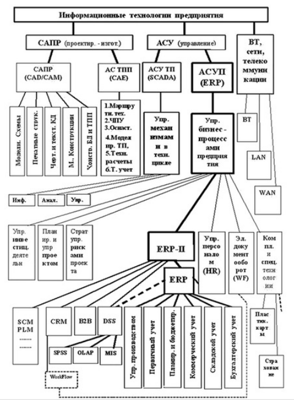

Остановимся на ряде аббревиатур и терминов:

- **Система автоматизированного проектирования или система автоматизации проектных работ (англ. Computer-aided design (CAD))** — автоматизированная система CAD, реализующая информационную технологию выполнения функций проектирования, представляет собой организационно-техническую систему, предназначенную для автоматизации процесса проектирования, состоящую из персонала и комплекса технических, программных и других средств автоматизации его деятельности.
- **CAE** (англ. Computer-aided engineering) — общее название для программ и программных пакетов, предназначенных для решения различных инженерных задач: расчётов, анализа и симуляции физических процессов. Расчётная часть пакетов чаще всего основана на численных методах решения дифференциальных уравнений (см.: метод конечных элементов, метод конечных объёмов, метод конечных разностей и др.).
- **SCADA** (аббр. от англ. Supervisory Control And Data Acquisition — диспетчерское управление и сбор данных) — программный пакет, предназначенный для разработки или обеспечения работы в реальном времени систем сбора, обработки, отображения и архивирования информации об объекте мониторинга или управления.
- **ERP** (англ. enterprise resource planning, планирование ресурсов предприятия) — организационная стратегия интеграции производства и операций, управления трудовыми ресурсами, финансового менеджмента и управления активами, ориентированная на непрерывную балансировку и оптимизацию ресурсов предприятия посредством специализированного интегрированного пакета прикладного программного обеспечения, обеспечивающего общую модель данных и процессов для всех сфер деятельности.
- **PLM (product lifecycle management)** - управление жизненным циклом продукции.
- **Управление цепочками поставок (англ. Supply Chain Management (SCM))** — управленческая концепция и организационная стратегия, заключающаяся в интегрированном подходе к планированию и управлению всем потоком информации о сырье, материалах, продуктах, услугах, возникающих и преобразующихся в логистических и производственных процессах предприятия, нацеленном на измеримый совокупный экономический эффект (снижение издержек, удовлетворение спроса на конечную продукцию).
- **Система управления взаимоотношениями с клиентами (CRM, CRM-система, сокращение от англ. Customer Relationship Management)** — прикладное программное обеспечение для организаций, предназначенное для автоматизации стратегий взаимодействия с заказчиками (клиентами), в частности, для повышения уровня продаж, оптимизации маркетинга и улучшения обслуживания клиентов путём сохранения информации о клиентах и истории взаимоотношений с ними, установления и улучшения бизнес-процессов и последующего анализа результатов.
- **Бизнес для бизнеса» («B2B»)** (англ. «business-to-business» — рус. «бизнес для бизнеса», сокращённо произносится — «би ту би») — термин, определяющий вид информационного и экономического взаимодействия, классифицированного по типу взаимодействующих субъектов, в данном случае это — юридические лица, работающие не на конечного рядового потребителя, а на такие же компании, то есть на другой бизнес.
- **Система поддержки принятия решений (СППР) (англ. Decision Support System, DSS)** — компьютерная автоматизированная система, целью которой является помощь людям, принимающим решение в сложных условиях для полного и объективного анализа предметной деятельности.
- **SPSS Statistics (аббревиатура англ. «Statistical Package for the Social Sciences»** — «статистический пакет для общественных наук») — компьютерная программа для статистической обработки данных, один из лидеров рынка в области коммерческих статистических продуктов, предназначенных для проведения прикладных исследований в общественных науках.
- **OLAP (англ. online analytical processing, интерактивная аналитическая обработка)** — технология обработки данных, заключающаяся в подготовке суммарной (агрегированной) информации на основе больших массивов данных, структурированных по многомерному принципу. Реализации технологии OLAP являются компонентами программных решений класса Business Intelligence.
- **Поток работ (англ. workflow)** — графическое представление потока задач в процессе и связанных с ним подпроцессах, включая специфические работы, информационные зависимости и последовательность решений и работ.

В целом мы подошли к важному понятию **управления информационными ресурсами предприятия**. По большому счету все перечисленные процессы направлены на управление информационными ресурсами и связаны с порождением информационных ресурсов, их хранением, обработкой, передачей, обновлением и т.д. Обобщенно **управление информационными ресурсами можно декомпозировать через пять основных функций управления**:

- **планирование** - формирование и планирование информационной базы, технологий предприятия для решения стратегических и оперативных задач.
- **организация** - создание информационной компоненты предприятия, внедрение выбранных технологий и информационных систем.
- **мотивация** - стимулирование и поэтапное внедрение автоматизации на предприятии (охват все больших участков, узлов и агрегатов).
- **руководство** - координация взаимодействия различных подсистем порождения информационных процессов.
- **контроль** - анализ соблюдения регламентов заполнения данных, обеспечения конфиденциальности данных.

## 4. Интегрированные информационные системы управления информационными ресурсами предприятий.

Корпоративные информационные системы (КИС) играют в наше время очень важную роль в производстве и бизнесе.

Основой КИС предприятий на современном этапе являются так называемые системы планирования ресурсов предприятий (Enterprise Recourse Planning — ERP)

Построение корпоративной информационной системы должно начинаться с анализа структуры управления организацией и соответствующих потоков данных и информации.

Первым шагом на пути к эффективному управлению является создание системы сбора, оперативной обработки и получения оперативной, точной и достоверной информации о деятельности предприятия — системы для реализации управленческого учёта.

Эти требования могут быть реализованы при соблюдении ряда принципов построения системы для формирования управленческой отчетности:

- система должна быть ориентирована на лиц, принимающих решения и на сотрудников аналитического отдела;
- система должна строиться <<сверху вниз>>, руководители каждого уровня должны проанализировать состав и периодичность необходимых им для выполнения своей работы данных;
- исполнители должны иметь возможность фиксирования и передачи <<наверх>> установленных их руководством данных;
- данные должны фиксироваться там, где порождаются;
- информация разной степени детализации должна становиться доступной всем заинтересованным потребителям сразу же после ее фиксирования.

Для любого предприятия возможность повышения эффективности производства в первую очередь определяется эффективностью существующей системы управления, которая включает в себя: скоординированное взаимодействие между всеми подразделениями, оперативная обработка и анализ получаемых данных, долговременное планирование и прогнозирование состояния рынка.

Комплексное внедрение систем автоматизации включает в себя:

- автоматизацию многих направлений деятельности предприятия (бухгалтерский учет, управление персоналом, сбыт, снабжение и т. д.);}
- автоматизацию основных технологических процессов предприятия;
- автоматизацию собственно управленческих процессов, процессов анализа и стратегического планирования.

В настоящее время в мировой практике для обозначения полнофункциональных интегрированных АСУ, используемых фирмами, применяют названия:

- **MRP (Material Requirement Planning — Планирование материальных потребностей);**
- **MRP II (Manufacturing Resource Planning — Планирование производственных ресурсов);**
- **ERP-система (Enterprise Resource Planning —Планирование ресурсов предприятия);**
- **ERP-II и CSRP (Customer Synchronized Relationship Planning) — Планирование ресурсов, синхронизированное с покупателем).**

**Эволюция систем управления предприятием**

**Этап 1**: системы обработки данных, в которых пользователь "напрямую" участвовал в постановке задачи и получении результата. Этот период продолжался с начала 60-х годов ХХ века до начала 90-х. Для информационных систем планирования ресурсов производства в это время был сформулирован стандарт MRPII.

**Этап 2**: начал активно использоваться многопользовательский режим работы с общесистемными ресурсами. В этот период времени сформировались основные принципы построения, разработки и эксплуатации ERP-систем предприятий. Этот период продолжался с конца 90-х годов ХХ века до начала 2000-х годов.

**Этап 3**: 2000-й год ознаменовался <<бумом>> Интернет-технологий. К настоящему времени можно уверенно говорить о переходе корпоративных систем на следующий этап эволюции: организация прямого межкорпоративного взаимодействия с поставщиками и корпоративными заказчиками, а также с рядовыми клиентами. Для классификации систем нового поколения стали применять термины ERP-II и CSRP.

**Схема послойной компоновки современной КИС**

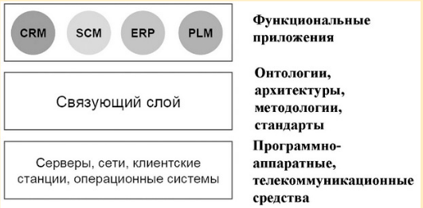

Одной из важнейших составляющих управленческой деятельности на любом предприятии является эффективное планирование деятельности. Необходимость планирования вызвана тем, что основные задержки в производстве продукции связаны, в первую очередь, с неритмичными поставками заказанного оборудования и комплектующих изделий. Вследствие этого снижается эффективность производства (из-за недопроизводства продукции), а на складах возникает переизбыток материалов, поступивших ранее намеченного срока, скапливается готовая и внеплановая продукция. Кроме того, из-за нарушения баланса поставок комплектующих возникают различные сложности с их учетом в процессе производства и сопровождения продукции.

Первые реализации возможностей использования средств вычислительной техники для планирования деятельности предприятий (в том числе, планирования производственных процессов) возникли еще в начале 60-х годов ХХ века.

Алгоритм работы такой системы был следующим: на входе задаются основной производственный план (MPS) и список номенклатуры изделий (IM). Далее производится операция <<раскрытие>> — расчет себестоимости и/или потребности в материалах. В результате расчета получается план закупок.

Естественное развитие таких систем — добавить учет запасов на складах и учет времени выполнения операции. В результате получается: план закупок и план производства + исправление к планам, если меняется портфель заказов.

Такие корпоративные системы получили название "Планирование материальных потребностей предприятия" (Material Requirement Planning — MRP).

Главной задачей MRP-систем является обеспечение наличия на складе и в производственных помещениях необходимого количества требуемых материалов (комплектующих) в любой момент времени в рамках срока планирования. Использование MRP-систем позволило уменьшить объем постоянных складских запасов за счёт оптимизации процесса поставок.

**Недостатки MRP**

- значительный объем вводимых данных и их предварительной обработки;
- возрастание логистических затрат на обработку заказов и транспортировку при стремлении фирмы ещё больше уменьшить запасы материальных ресурсов или перейти на работу с малыми заказами с высокой частотой их выполнения;
- нечувствительность к кратковременным изменениям спроса;
- наличие отказов из-за большой размерности системы и ее сложности.

**Стандарт MRP II**

При расчете потребности в материалах в MRP-системах не учитываются производственные мощности, величина и неравномерность их загрузки, стоимость рабочей силы и т. д. В конце 70-х гг. ХХ века методология MRP-систем с замкнутым циклом была трансформирована в систему планирования производственных ресурcов в масштабах предприятия (Manufactory Resource Planning), которая получила название MRP II (римскую цифру II добавили вследствие идентичности аббревиатур).

Стандарт MRPII был разработан в США и поддерживается Американским обществом по управлению производством и запасами (American Production and Inventory Control Society — APICS). В свое время при поддержке APICS был издан документ "MRP II Standard System", в котором описываются основные требования к информационным производственным системам.

В соответствии с "MRP II Standard System", в информационной системе, реализованной на базе стандарта MRP II, должны быть реализованы следующие 16 групп функций:

- Планирование продаж и производства (Sales and Operation Planning).
- Управление спросом (Demand Management).
- Составление плана производства (Master Production Scheduling).
- Планирование потребностей в материалах (Material Requirement Planning).
- Спецификация продуктов (Bill of Materials).
- Управление складом (Inventory Transaction Subsystem).
- Плановые поставки (Scheduled Receipts Subsystem).
- Управление на уровне производственного цеха (Shop Flow Control).
- Планирование производственных мощностей (Capacity Requirement Planning).
- Контроль входа/выхода (Input/Output Control).
- Материально-техническое снабжение (Purchasing).
- Планирование распределения ресурсов (Distribution Resourse Planning).
- Планирование и контроль производственных операций (Tooling Planning and Control).
- Финансовое планирование (Financial Planning).
- Моделирование (Simulation).
- Оценка результатов деятельности (Performance Measurement).

**Общая схема планирования ресурсов производственного предприятия**

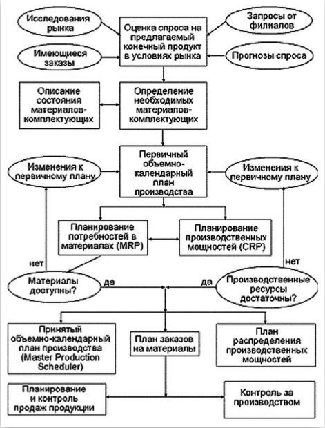

**Стандарт ERP**

В начале 90-х гг. аналитическая компания Gartner Group ввела новое понятие. Системы класса MRP II в интеграции с модулем финансового планирования (Finance Requirements Planning — FRP) получили название систем планирования ресурсов предприятий (Enterprise Resource Planning — ERP). Иногда также встречается термин <<планирование ресурсов в масштабах предприятия>> (Enterprise-Wide Resource Planning).

В основе ERP-систем лежит принцип создания единого хранилища (репозитория) данных, содержащего всю корпоративную бизнес-информацию: плановую, финансовую, производственную, данные по персоналу и др. Наличие единого корпоративного репозитория устраняет необходимость в передаче данных от одной системы к другой (например, от производственной системы к финансовой или к кадровой). Такая система обеспечивает также одновременную доступность к информации любого числа сотрудников предприятия, обладающих соответствующими полномочиями. Целью ERP-систем является не только улучшение управления производственной деятельностью предприятия, но и уменьшение затрат и усилий на поддержку его внутренних информационных потоков.

В 1990 году была предложена следующая формула ИС на базе Enterprise Resource Planning:

$$ERP = MRP2 + FRP +DRP$$

где планированию подлежат не только материалы и время рабочих центров, но и финансовые ресурсы FRP, DRP — управление ресурсами дистрибуции.

**Основные функции ERP систем**:

- ведение конструкторских и технологических спецификаций, определяющих состав производимых изделий, а также материальные ресурсы и операции, необходимые для его изготовления;
- формирование планов продаж и производства;
- планирование потребностей в материалах и комплектующих, сроков и объемов поставок для выполнения плана производства продукции;
- управление запасами и закупками: ведение договоров, реализация централизованных закупок, обеспечение учета и оптимизации складских и цеховых запасов;
- планирование производственных мощностей от укрупненного планирования до использования отдельных станков и оборудования;
- оперативное управление финансами, включая составление финансового плана и осуществление контроля его исполнения, финансовый и управленческий учет;
- управления проектами, включая планирование этапов и ресурсов, необходимых для их реализации.

**Стандарт ERP II**

Позже в ERP-системы стали включать дополнительный модуль APS (Advanced Planning and Scheduling) — методику планирования, использующую методы математической оптимизации в составлении календарных планов, так как для решения даже вроде бы простых по постановке задач дискретного планирования для распределенной дистрибьюторской сети обыкновенные алгоритмы становятся неработоспособными из-за большой размерности обрабатываемых данных.

В конце 90-х гг. ХХ века была разработана также методология "Планирование ресурсов предприятия, синхронизированное с запросами потребителя" (Customer Synchronized Resource Planning — CSRP), которая охватывает взаимодействие предприятия с клиентами: оформление наряд-заказа, техническое задание, поддержку клиентов, планирование ресурсов в зависимости от объема и состава клиентских заказов.

Если стандарты MRP/MRPII/ERP ориентированы на управление запасами и мощностями, планирование, производство и продажу продукта, то в стандарт CSRP включен полный цикл жизненного цикла изделия — от его проектирования с учетом требований заказчика до гарантийного и сервисного обслуживания после продажи.

Этот новый тип КИС в некоторых источниках стали называть системой ERP II, основа которых — управление взаимодействием компании с внешней средой. Там где можно, внутренние и конфиденциальные процессы становятся внешними и открытыми. Излишняя тайна корпоративной информации, которая усложняла деятельность, исчезает. На смену ей приходит чётко регламентированная политика в сфере информационной безопасности и безопасности самих информационных систем.

Ниже показаны основные функциональные блоки типизированной ERP-системы:

- Управление спросом. Блок предназначен для прогноза будущего спроса на продукцию, определения объема заказов, которые можно предложить клиенту в конкретный момент времени, определения спроса дистрибьюторов, спроса в рамках предприятия и др.
- Планирование продаж и производства. Результатом действия блока является разработка плана производства основных видов продукции.
- Укрупненное планирование мощностей. Используется для конкретизации планов производства и определения степени их выполнимости.
- Основной план производства (план-график выпуска продукции). Определяется продукция в конечных единицах (изделиях) со сроками изготовления и количеством.
- Планирование потребностей в материалах. Определяются виды материальных ресурсов (сборных узлов, готовых агрегатов, покупных изделий, исходного сырья, полуфабрикатов и др.) и конкретные сроки их поставки для выполнения плана.
- Спецификация изделий. Определяет состав конечного изделия, материальные ресурсы, необходимые для его изготовления, и др. Фактически спецификация является связующим звеном между основным планом производства и планом потребностей в материалах.
- Планирование потребностей в мощностях. На данном этапе планирования более детально, чем на предыдущих уровнях, определяются производственные мощности.
- Маршрутизация/рабочие центры. С помощью этого блока конкретизируются как производственные мощности различного уровня, так и маршруты, в соответствии с которыми выпускаются изделия.
- Проверка и корректировка цеховых планов по мощностям.
- Управление закупками, запасами, продажами.
- Управление финансами (ведение Главной книги, расчеты с дебиторами и кредиторами, учет основных средств, управление наличными средствами, планирование финансовой деятельности и др.).
- Управление затратами (учет всех затрат предприятия и калькуляция себестоимости готовой продукции или услуг).
- Управление проектами/программами.
- Управление персоналом.

Основой ERP-системы является ядро, реализованное на базе стандарта MRP II. Тем не менее, ERP-система не является простым расширением системы MRP. MRP-система была построена и развивалась как замкнутая система, обслуживающая сугубо внутренние потребности предприятия. ERP-система имеет выходы во внешнюю среду и предназначена для решения задач комплексного управления предприятием.

Классические ERP-системы, в отличие от так называемого "коробочного" программного обеспечения, относятся к категории "тяжелых" программных продуктов, требующих достаточно длительной настройки, для того чтобы начать ими пользоваться. Выбор КИС, приобретение и внедрение, как правило, требуют тщательного планирования в рамках длительного проекта с участием партнерской компании — поставщика или консультанта.

Поскольку КИС строятся по модульному принципу, заказчик часто (по крайней мере, на ранней стадии таких проектов) приобретает не полный спектр модулей, а ограниченный их комплект. В ходе внедрения проектная команда, как правило, в течение нескольких месяцев осуществляет настройку поставляемых модулей.

Выбор готового решения — это всегда сложная и ответственная задача. Намерение предприятия приобрести и внедрить ИС зависит от многих факторов — от его внутренней готовности произвести реинжиниринг бизнес-процессов до цены и времени внедрения ИС.

**Соотношение размеров бизнеса и типа интегрированной ИС**

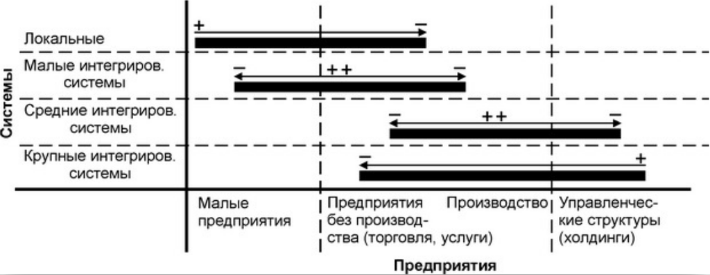

**Соотношение стоимостных оценок внедрения**

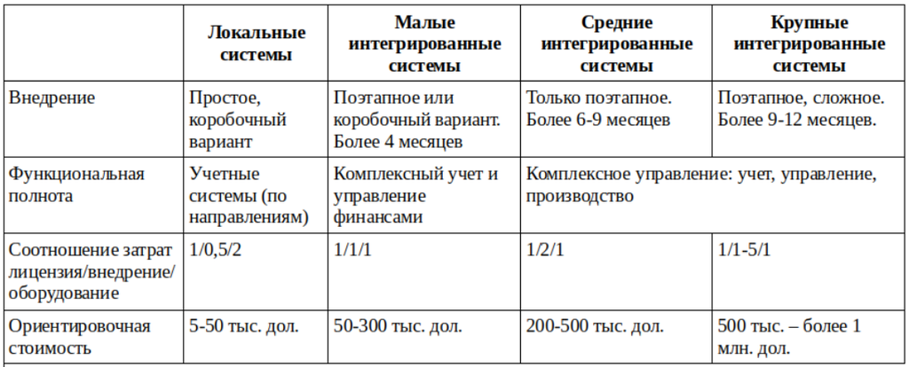

**Наиболее известные отечественые производители (поставщики) современных ERP-систем**

- [ПАРУС (Корпорация "Парус")](http://www.parus.ru)
- [Галактика (Корпорация "Галактика")](http://www.galaktika.ru)
- [1С: Предприятие (Компания 1С)](http://www.1c.ru)